# ΜΙΣΤΑ003 : Selection of studies

## Selection of studies

**Study selection process**

After retrieving the search results, the next stage is to identify those studies that satisfy the eligibility criteria for the systematic review.

A typical process for selecting studies for inclusion in a systematic review involves the following steps:

1. Merging search results using a reference management software, such as [MENDELEY](https://www.mendeley.com/), and subsequently remove duplicate records of the same report
2. Assess the title and abstract of all remaining reports in order to exclude irrelevant reports
3. Examine the full text of potentially relevant reports
4. Make final decisions on study inclusion.

Decisions about which studies to include in a review involve judgement. Thus, it is possible for a reviewer to make a mistake concerning the inclusion or exclusion, due to various reasons:

- A reviewer may miss relevant information and exclude a citation by mistake
- The inclusion and exclusion criteria may not be well-reported or clearly defined in the title and abstract of a report

Therefore, it is preferable that the study selection process is undertaken by more than one reviewer. Disagreements about whether a study should be included can generally be resolved by consensus.

**Reporting the study selection process**

Any systematic review should report the number of reviewers involved in the study selection process and how potential inconsistencies between reviewers were resolved.

Specific details about the reporting of the search results and how the reviewers have arrived at their final number of included studies is presented at the [Preferred Reporting Items for Systematic Reviews and Meta-Analyses](http://www.prisma-statement.org/) (**PRISMA**) statement. More specifically, PRISMA is an evidence-based minimum set of items for reporting in systematic reviews and meta-analyses and among other instructions it includes a flowchart regarding the study selection process.

Templates for a **PRISMA flowchart** are available [here](http://www.prisma-statement.org/PRISMAStatement/FlowDiagram) and an example is presented below.

The purpose of this diagram is to provide transparency and reproducibility of the whole study selection procedure. It is essential that every systematic review should report a PRISMA flowchart such as this:

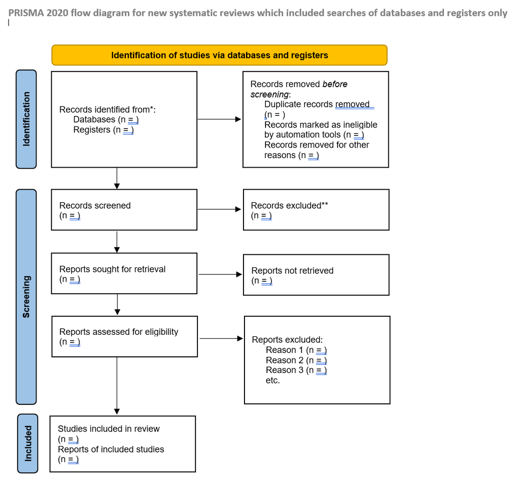

Last modified: Saturday, 22 May 2021, 11:38 AM